# Likelihood from binomially & Poisson distributed data

alekssro

# ExampleA: example 20.3 from AGD Book

### Walk through example

```r
nT=32
Yobs=23
```

The likelihood function is based on a specific choice:  
- Yobs is assumed to be binomial with unknown probabilty p and represents the number of wasps who choose mated females. - nT is the number of trials.  
Here p is the parameter we want to estimate from the data.

```r
likelihoodWasp=function(p){
  return(dbinom(x = Yobs,size = nT,prob = p,log = F))
}
```

When making likelihood calculation we often work with the so called LogLikelihood (on a) this is merely the natural log tof the the likelihood function)

```r
LoglikelihoodWasp=function(p){
  return(dbinom(x = Yobs,size = nT,prob = p,log = T))
}
```

The fuction defined above is only a function of one parameter because the number of trials (nT) and the observed number of “success” Yobs are the data and hence fixed.

Getting the likelihood of a specific parameter value:

```r
LoglikelihoodWasp(0.7)
```

```
## [1] -1.889823
```

```r
LoglikelihoodWasp(0) ## what happened here ?
```

```
## [1] -Inf
```

Representing the likelihood function (using base fucntion you can also use ggplot)

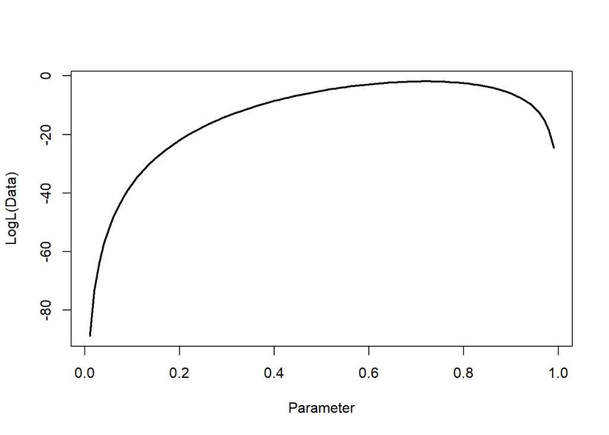

```r
xs=seq(from = 0.01,to = 0.999, by=0.01) # the points at which we want to evaluate the likelihood
ys=LoglikelihoodWasp(xs) # here we give a vector to the function
plot(xs,ys, xlab="Parameter", ylab="LogL(Data)", type="l", lwd=2)
```

Zooming around the region of the maximum:

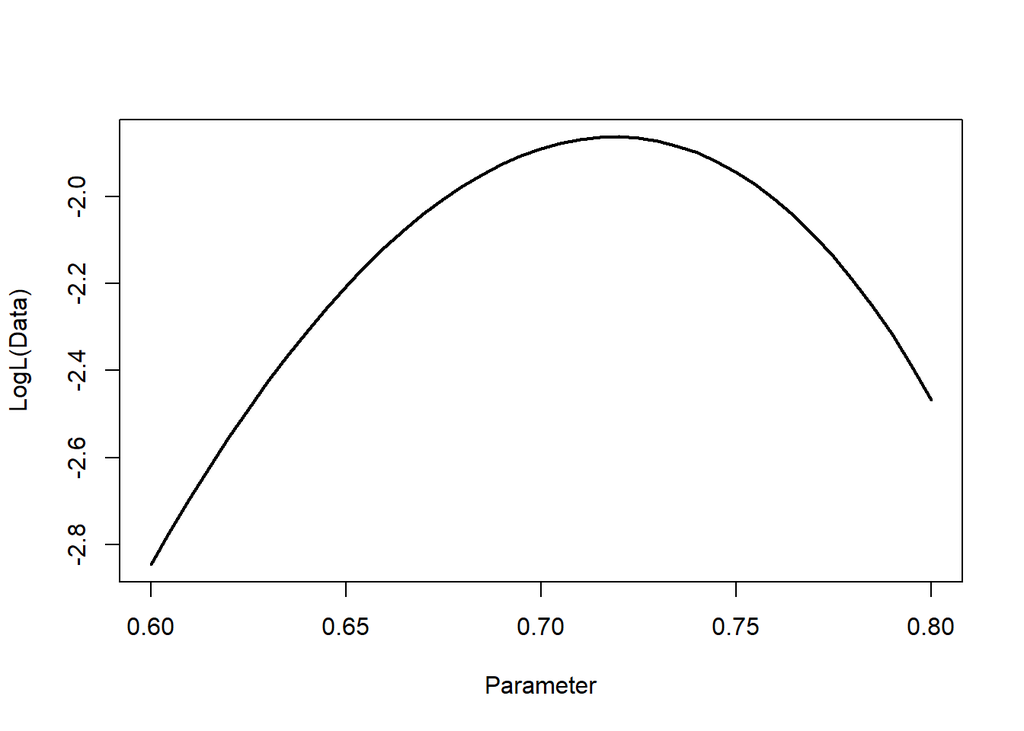

```r
xs=seq(from = 0.6,to = 0.8, by=0.005) # the points at which we want to evaluate the likelihood
ys=LoglikelihoodWasp(xs) # here we give a vector to the function
plot(xs,ys, xlab="Parameter", ylab="LogL(Data)", type="l", lwd=2)
```

### Finding the MLE over a grid of possible parameters:

- finding the mle directly:

```r
maxL=max(ys)
```

-finding the value of xs maximizing ys:

```r
which.max(ys) ##finding the index position of the max in the ys vector
```

```
## [1] 25
```

```r
xs[which.max(ys)] ##you get the value at the index position of the max in the ys vector.
```

```
## [1] 0.72
```

> NB another alternative is to find numerically the maximum of the function.

Not needed here but often used in practice when more than 2 parameters are involved in the likelihood function

Note that in that very simple case the MLE is known analytically: MLE is just p=yobs/nT for the binomial case… Does it make sense ?

```r
Yobs/nT
```

```
## [1] 0.71875
```

## Likelihood based confidence interval for the population parameter(reproducing fig 20-3-2):

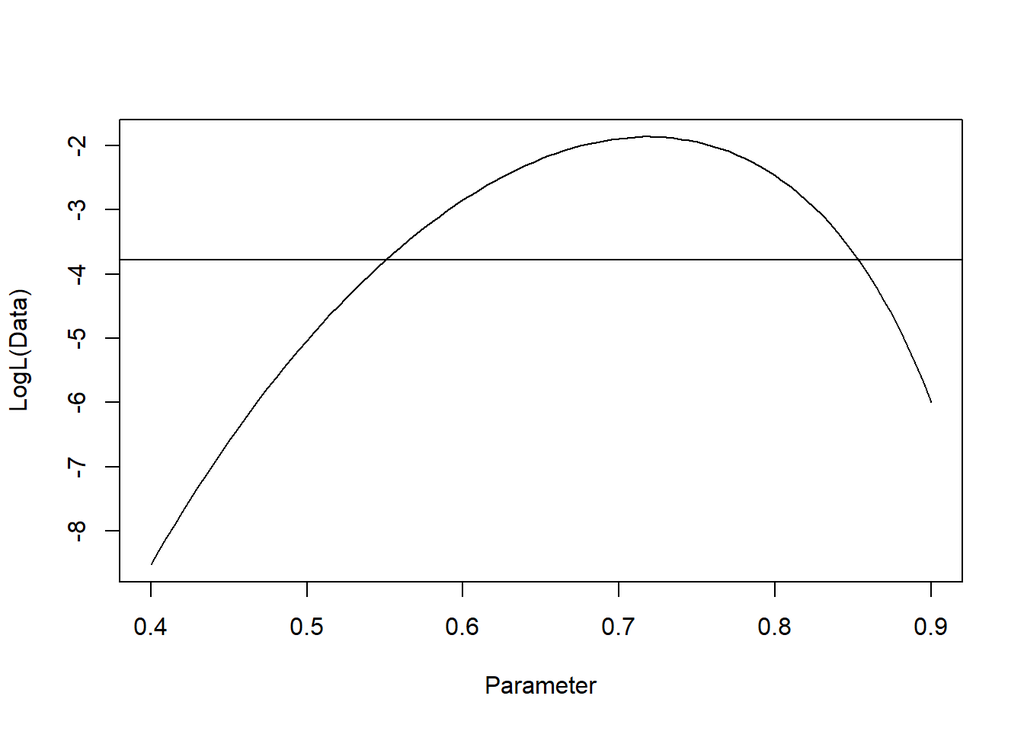

```r
xs=seq(from = 0.4,to = 0.9, by=0.005) # the points at which we want to evaluate the likelihood
ys=LoglikelihoodWasp(xs) # here we give a vector to the function
plot(xs,ys, xlab="Parameter", ylab="LogL(Data)", type="l")
abline(h = maxL-1.92)
```

## About the confidence interval:

The confidence interval for the parameter p-real is the one where values pobs are not significantly different from p-real. This can be tested with a chi-2 test on the likelihood ratio, which reject H0 with a risk of 0.05 if the ratio is above 3.84.  
The likelihood ratio test is `2[loglikelihood(p-real)-loglikelihood(pobs)]`, so we reject H0 if likelihood(pobs)<=likelihood(p-real)-1.92 which is the horizontal line we just drew.

### The loglikelihood ratio test statistic and its associated p-value:

```r
G = 2 * (LoglikelihoodWasp(0.72) - LoglikelihoodWasp(0.5))
G
```

```
## [1] 6.33685
```

Under the hypothesis Ho: p=0.5, we expect G to be Chi^2 with 1 df. So any G value above 3.84 (the 0.95 cutoff of a Chi^2 with 1.d.f) is rejecting Ho at the 0.05 level

```r
qchisq(0.95,df=1) #(qchisq gives you the minimum chi square value where 95 of the values falls.)
```

```
## [1] 3.841459
```

## Supplementary Questions based on the same example

#### Question 1: Find the boundaries of the confidence interval

Hint: find the subset of xs that give a LogL within 1.92 of the maximum value

```r
maxL=max(ys)
min(xs[ys > maxL - 1.92])
```

```
## [1] 0.555
```

```r
max(xs[ys > maxL - 1.92])
```

```
## [1] 0.85
```

#### Question 2: First using the R function giving the CDF of chi^2 distibution, find the p value associated with G.

! Reminder: cumulative function= P(X<=x).

```r
ecdf(dchisq(G, df=1))
```

```
## Empirical CDF
## Call: ecdf(dchisq(G, df = 1))
##  x[1:1] = 0.0066672
```

#### Question 3. Check the accuracy of the assumption of the Likelihood ratio test regarding the Chi^2 distribution of the G statistic.

To do so Generate 10,000 datasets under the null hypothesis: ie in that case nT=32, and p=1/2 and for each simulated dataset, compute G. Compare visually the simulated distribution for G under Ho and the Chi^2 distribution with 1 d.f. that is classically used to approximate that distribution.

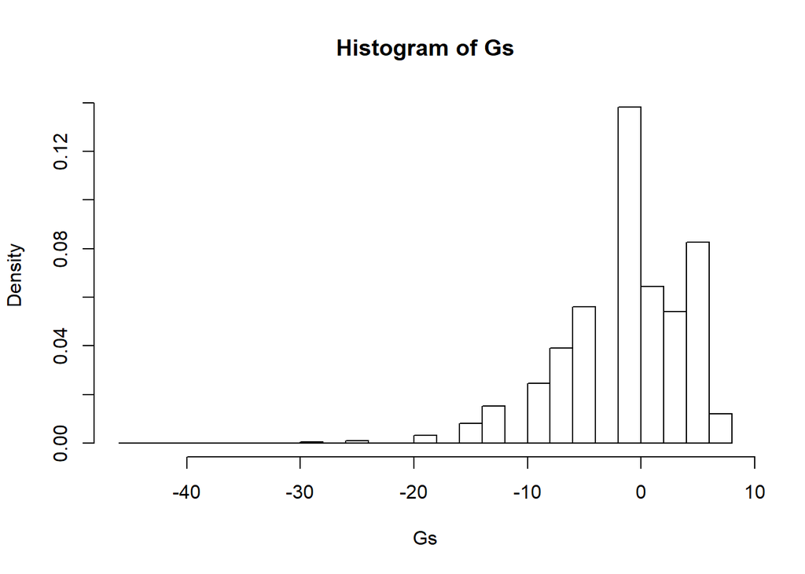

```r
nT = 32
Gs <- rep(0, 10000)
Gs <- replicate(10000, {
    Yobs = rbinom(n = 1, size = 32, prob = 0.5)
    2 * (LoglikelihoodWasp(Yobs / nT) - LoglikelihoodWasp(0.5))
})
hist(Gs, breaks = 25, freq = F)
```

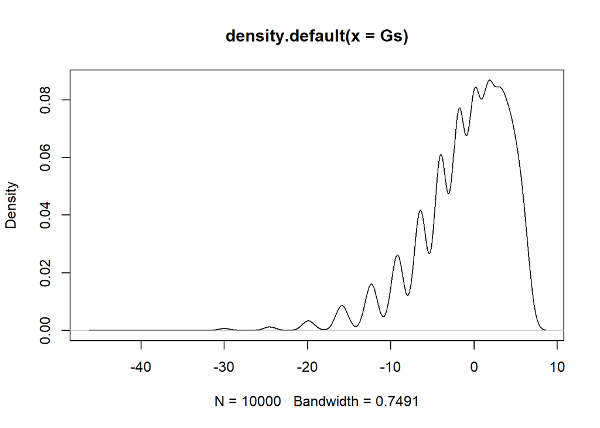

```r
plot(density(Gs))
```

#### Question 4: Imagine the same experiment was repeated with a larger sample size but the same observed proportion (in practice it is not likely but lets assume that ;-)).

Graph and compare the likelihood profiles for the three datasets on the same graph

- Dataset 1: nT = 32, Yobs =23
- Dataset 2: nT = 64, Yobs= 46
- Dataset 3 nT=160, Yobs = 115

Recalculate the likelihood ratio test and its associated p-value for each dataset

```r
nTtest = c(32, 64, 160)
Yobstests = c(23, 46, 115)
colours = c("black", "orange", "red")
pvalratio = rep(0, 3)
```

# Example B: Whole Genome resequencing of genomes stemming from an experimental evolution design

### Background

A number of lines of bacteria have been transferred regularly in the lab (so called experimental evolution). Lines were founded from the same ancectral genotype but with some specific genes “knocked out”

Data consists in observed counts of SNPs detected relative to the Nod+ ancestor at the end of the experiment

We have as data:

in the hrpg(STOP) background 6 experimental lines (Tgens of evolution in each line) yielding in total 39+47+84+48+46+86 =350 SNPs mutations in the hrcv(STOP) background 3 exp lines (Tgens in each line) yielding in total 33+38+25 = 96 SNPs mutations The number of point mutations (SNPs) detected in the experimental lines suggests that lines evolving in the hrpg(STOP) background undergo a higher mutation rate relative to the lines evolving from a hrcv(STOP) ancestor. The purpose of the questions below is to explore whether there is statistical evidence for that assertion using a likelihood framework. Model Assumptions for calculating the likelihood of the data: The mutation process is assumed to be a Poisson (stochastic) process with rate $\lambda= Tgens*\mu$, where Tgens is the actual number of generation separating the ancestral strains from the resequenced strains at the end of the experiment and mu the mutation rate (define per genome and per generation)

Here, we assume that Tgens is 600 but note that although it will affect the actual per genome per generation mutation rate estimates (it will scale it accordingly) it does not affect the finding i.e. that the genome have a different mutation rate or not if Tgens in unknown but identical for all lines.

mu is defined as a mutation rate per genome and per generation for point mutations (SNPs). In all rigor this is a mutation rate per “effectively covered genome” (defined over the fraction of the genome that is covered by reads that can be mapped without ambiguity).

So in practice, an important point to check is that the fraction of the genome covered by reads in each experimental line is not widely different.. and if so to calculate a relative genome coverage for each experimental line… but here we assume that the number of nucleotide over which SNP mutations could be “called” is identical.

### Questions

#### Question 1: Write down the likelihood function as a function of a single parameter we will call U which is defined as the per genome per generation mutation rate and as a function of the observed data which is the number of SNPs.

Hint: use the density of a poisson distribution dpois()

#### Question 2: For each genomic background find the MLE of U and an approx 95% confidence interval for U.

#### Question3: Use a likelihood ratio test to compare a null model where both genomic background have identical mutation rate U versus an alternative model where U1 and U2 are background specific mutation rates for respectively the hrpg(STOP) and hrcv(STOP) background.

Hint: here we compare a null model with 1 fitted parameter (U) to an alternative model with two fitted parameters (U1 and U2) so in principle the G statistic of the Likelihood ratio test should be Chi^2 with 1 d.f if under the null hypothesis that both genomic background have identical U.

#### Question 4: Imagine that the experiment could be running for potentially 2, 5 or 10 times as long, i.e. Tgens= 1200, 3000 or 6000 generations.

Assume 2 lines are re-sequenced in each background. For each value of Tgens, what would be the probability of such an experiment to detect a 20% change in mutation rate if we assume that one background has mutation rate U1=0.05 per genome per gen and the other has U2 = 0.06 per genome per gen?

We further assume that we reject the null if the likelihood ratio test for comparing a model with two backgrounds genome mutation rates versus a single one has a p-value smaller than alpha=0.05.